[figure not shown]

[figure not shown]

757 R Users Group: http://www.meetup.com/757-R-Users-Group/

# Working with APIs from R

Steve Mortimer and Chris Brossman  
November 15, 2016

### 2 Common Webservice API Types

**Resources:**  
[The Difference Between SOAP and REST](http://spf13.com/post/soap-vs-rest)  
[SOAP vs REST Challenges](http://www.soapui.org/testing-dojo/world-of-api-testing/soap-vs--rest-challenges.html)

SOAP  
**S**imple **O**bject **A**ccess **P**rotocol

- Protocol agnostic  
  (HTTP, SMTP, TCP, or JMS)
- Typically XML
- Strongly Typed
- Definitions provided by WSDL (**W**eb **S**ervice **D**escription **L**anguage)

REST  
**Re**presentational **S**tate **T**ransfer

- Noun-Verb Paradigm  
  (HTTP GET/POST/PUT/DELETE)
- Typically formatted as JSON (**J**ava**s**cript **O**bject **N**otation)

### 2 Common API Data Formats

XML

```
<person>
  <firstname>Rick</firstname>
  <lastname>James</lastname>
  <occupation>legend</occupation>
</person>
```

- Favored by SOAP APIs
- Traditional format

JSON

```
{
  "person": {
    "firstname": "Rick",
    "lastname": "James",
    "occupation": "legend"
  }
}
```

- Favored by REST APIs
- A more modern, flexible approach

### HTTP

**Resources:**  
[Extracting data from the web: APIs and beyond](https://github.com/ropensci/user2016-tutorial/blob/master/slides.pdf)

- Verbs for different actions
  - GET, PUT, POST, DELETE
- Authentication
  - None, Basic, OAuth 2.0
- Status codes
  - 200, 404, 403, 500
- Use httr for managing HTTP requests in R

  install.packages(‘httr’)

### Required Packages

Before you get started Run the snippet of code below

```r
options(stringsAsFactors = FALSE)

library(dplyr)
library(purrr)
library(httr)
library(jsonlite)
library(xml2)

options(httr_oauth_cache = TRUE)

# all of these packages are part of the tidyverse
# so you could run:
# install.packages('tidyverse'); library(tidyverse)
```

### API No Authentication (Just GET the URL)

The Open Movie Database API at: http://www.omdbapi.com/

```r
resp <- GET(paste0('http://www.omdbapi.com/',
                   '?t=The+Godfather&plot=short&r=xml'))
resp
```

```
Response [http://www.omdbapi.com/?t=The+Godfather&plot=short&r=xml]
  Date: 2016-11-11 22:45
  Status: 200
  Content-Type: text/xml; charset=utf-8
  Size: 843 B
```

```r
parsed_xml <- read_xml(content(resp, as="raw"))
parsed_xml
```

```
{xml_document}
<root response="True">
[1] <movie title="The Godfather" year="1972" rated="R" released="24 Mar  ...
```

### Parsing Many Elements

```r
resp <- GET(paste0('http://www.omdbapi.com/',
                   '?s=The+Godfather&plot=short&r=xml'))
resp
```

```
Response [http://www.omdbapi.com/?s=The+Godfather&plot=short&r=xml]
  Date: 2016-11-11 22:45
  Status: 200
  Content-Type: text/xml; charset=utf-8
  Size: 2.19 kB
```

```r
parsed_xml <- read_xml(content(resp, as="raw"))
parsed_xml
```

```
{xml_document}
<root totalResults="61" response="True">
 [1] <result title="The Godfather" year="1972" imdbID="tt0068646" type=" ...
 [2] <result title="The Godfather: Part II" year="1974" imdbID="tt007156 ...
 [3] <result title="The Godfather: Part III" year="1990" imdbID="tt00996 ...
 [4] <result title="The Godfather Trilogy: 1901-1980" year="1992" imdbID ...
 [5] <result title="The Godfather: A Novel for Television" year="1977" i ...
 [6] <result title="The Godfather" year="2006" imdbID="tt0442674" type=" ...
 [7] <result title="The Last Godfather" year="2010" imdbID="tt1584131" t ...
 [8] <result title="The Godfather II" year="2009" imdbID="tt1198207" typ ...
 [9] <result title="The Godfather Family: A Look Inside" year="1990" imd ...
[10] <result title="The Black Godfather" year="1974" imdbID="tt0071225"  ...
```

### Parsing Many Elements (cont.)

```r
# the values of a single result are stored
# as attributes inside the XML

# always test your strategies on one record
one_record <- parsed_xml %>%
  xml_find_all('result') %>%
  map(as_list) %>% .[[1]]

as.data.frame(attributes(one_record))[c('title', 'year', 'imdbID', 'type')]
```

```
          title year    imdbID  type
1 The Godfather 1972 tt0068646 movie
```

```r
# now work on them all
search_results <- parsed_xml %>%
  xml_find_all('result') %>%
  map(as_list) %>%
  map_df(function(x) as.data.frame(attributes(x)))
head(search_results[c('title', 'year', 'imdbID', 'type')])
```

```
                                  title year    imdbID   type
1                         The Godfather 1972 tt0068646  movie
2                The Godfather: Part II 1974 tt0071562  movie
3               The Godfather: Part III 1990 tt0099674  movie
4      The Godfather Trilogy: 1901-1980 1992 tt0150742  movie
5 The Godfather: A Novel for Television 1977 tt0809488 series
6                         The Godfather 2006 tt0442674   game
```

### We just learned: Grabbing Data from an API with No Authentication

### API with Basic Authentication

- Basic Authentication just means that your method of accessing a username or password
- The password may or may not be encrypted to prevent snatching as it goes across the web

```r
# There is an endpoint for testing that we
# can use instead of accessing a particular data API

url <- 'http://httpbin.org/basic-auth/user/passwd'
username <- "user"
password <- "passwd"
resp <- GET(url, config = authenticate("user", "passwd", "basic"))
content(resp, as="parsed")
```

```
$authenticated
[1] TRUE

$user
[1] "user"
```

### API with Basic (Digest) Authentication

- Digest Authentication means that the receiving server provides a special session key back that you can use when requesting information that is more secure than basic authentication

```r
# there is nothing inherently different about
# using digest authentication with httr compared to basic
# it's all managed behind the scenes

url <- 'http://httpbin.org/digest-auth/qop/user/passwd'
username <- "user"
password <- "passwd"
resp <- GET(url, config = authenticate("user", "passwd", "digest"))
content(resp, as="parsed")
```

```
$authenticated
[1] TRUE

$user
[1] "user"
```

### We just learned: Grabbing Data from an API with Basic Authentication

### API with Token/OAuth 2.0 Authentication

- OAuth is application-specific (Google, Facebook, Twitter)
- The user authorizes a “scope” (breadth of services) to get token

```r
# This uses Norfolk Data Science's key and secret
# If you want to create your own then you can register at:
# https://cloud.google.com/console#/project
key <- "414258752185-ln3is61lrs8r5jtq8695anopmplbjl4d.apps.googleusercontent.com"
secret <- "hPMYGZWmvNN9iqIRxkCeCWGy"
myapp <- oauth_app("google", key, secret)

# get the OAuth token
# this example requires a Google Drive account
google_token <- oauth2.0_token(oauth_endpoints("google"),
                               myapp,
                               scope = c("https://www.googleapis.com/auth/drive"))
google_token
```

```
<Token>
<oauth_endpoint>
 authorize: https://accounts.google.com/o/oauth2/auth
 access:    https://accounts.google.com/o/oauth2/token
 validate:  https://www.googleapis.com/oauth2/v1/tokeninfo
 revoke:    https://accounts.google.com/o/oauth2/revoke
<oauth_app> google
  key:    414258752185-ln3is61lrs8r5jtq8695anopmplbjl4d.apps.googleusercontent.com
  secret: <hidden>
<credentials> access_token, expires_in, token_type
---
```

### API with Token/OAuth 2.0 Authentication

- After you get your token, it's easy! Simply pass it along as an argument to the `GET` function

```r
# give your token to "GET" along with the URL
url <- 'https://www.googleapis.com/drive/v2/about'
req <- GET(url, google_token)

# parse the response
your_drive_metadata <- content(req, 'parsed')
your_drive_metadata$user[c(2,6)]
```

```
$displayName
[1] "Norfolk Data Science"

$emailAddress
[1] "norfolkdatasci@gmail.com"
```

```r
# calculate your GDrive Usage Percentage
sprintf("%1.2f%%", 100 *
          as.numeric(your_drive_metadata$quotaBytesUsed) /
          as.numeric(your_drive_metadata$quotaBytesTotal))
```

```
[1] "5.45%"
```

### Some more details on OAuth 2.0 Tokens

Image from a googlesheets packge vignette entitled: [Managing Auth Tokens](https://cran.r-project.org/web/packages/googlesheets/vignettes/managing-auth-tokens.html)

- Your script is an “application” working on sombody's behalf
- The user consents to your application's scope

[figure not shown]

- The token is returned to allow you to continue accessing given that authorization

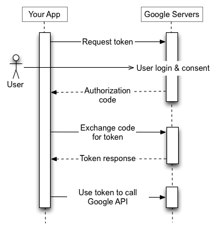

### We just learned: Grabbing Data from an API with Token or OAuth 2.0 Authentication